# Basic statistics

### cars 자료를 이용하여 속도 (speed)와 제동거리 (dist) 사이에 인과성을 판단하여라

```r
# lm(formula, data, subset, weights, na.action,
#    method = "qr", model = TRUE, x = FALSE, y = FALSE, qr = TRUE,
#    singular.ok = TRUE, contrasts = NULL, offset, ...)

lm.result <- lm(formula = dist ~ speed,
                data = cars)

summary(lm.result)
```

```
Call:
lm(formula = dist ~ speed, data = cars)

Residuals:
   Min     1Q Median     3Q    Max
-29.07  -9.53  -2.27   9.21  43.20

Coefficients:
            Estimate Std. Error t value Pr(>|t|)
(Intercept)  -17.579      6.758   -2.60    0.012 *
speed          3.932      0.416    9.46  1.5e-12 ***
---
Signif. codes:  0 '***' 0.001 '**' 0.01 '*' 0.05 '.' 0.1 ' ' 1

Residual standard error: 15.4 on 48 degrees of freedom
Multiple R-squared:  0.651, Adjusted R-squared:  0.644
F-statistic: 89.6 on 1 and 48 DF,  p-value: 1.49e-12
```

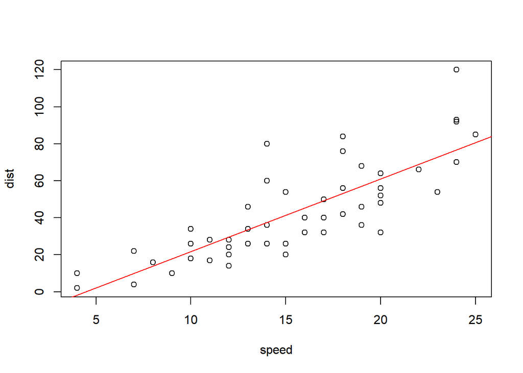

```r
plot(dist ~ speed, data = cars)
abline(lm.result, col = "red")
```

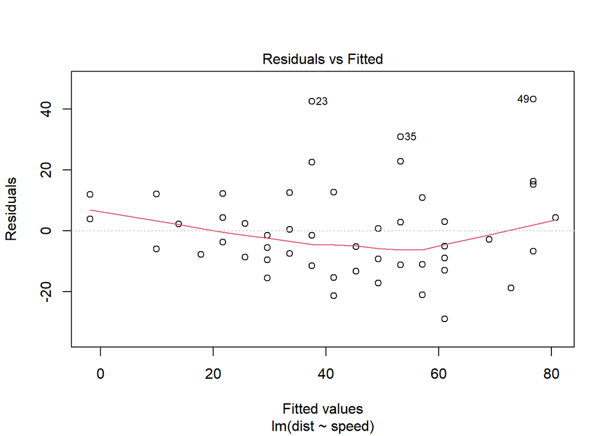

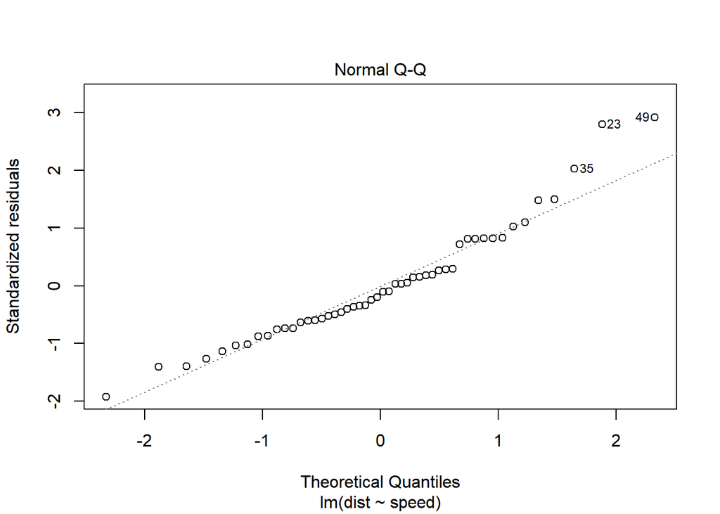

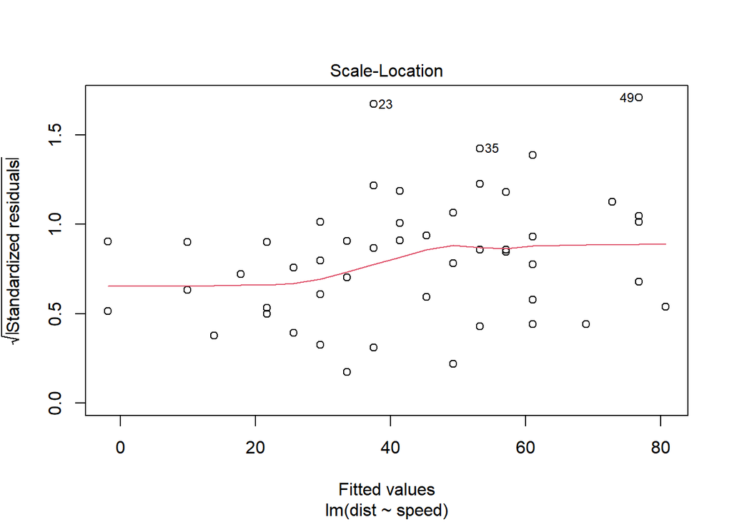

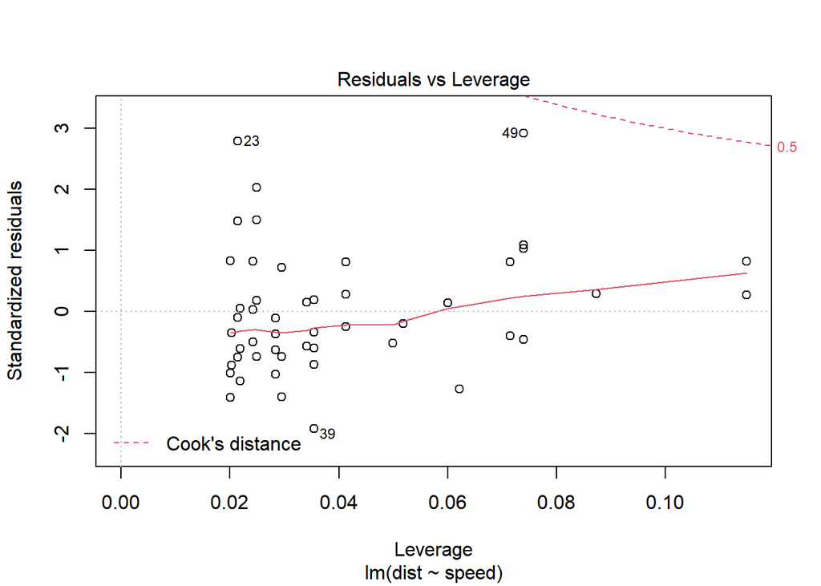

```r
plot(lm.result)
```

## 회귀계수의 추정 (예, 단순선형회귀분석의 경우)

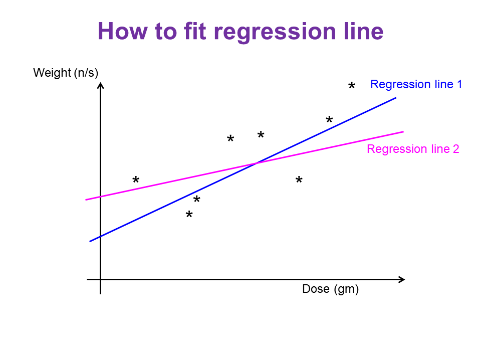

## 최소제곱 추정량 (Ordinary Least Square, OLS, estimation)

$$\large \hat\beta_o, \hat\beta_1 = min_{\hat\beta_0, \hat\beta_1}\sum_i^ne_i^2 = min_{\hat\beta_0, \hat\beta_1}\sum_i^n(y_i - \hat y_i)^2$$

- $\hat y_i = \hat\beta_0 + \hat\beta_1X_{i}$
- Sum of Squares of the Errors (SSE) = $\sum_i^ne_i^2$

$$\large \frac{\partial{SSE}}{\partial{\hat{\beta_0}}} = 0, \ \ \ \hat{\beta_0} = \overline{y} - \hat{\beta_1}\overline{x}$$

$$\large \frac{\partial{SSE}}{\partial{\hat{\beta_1}}} = 0,\ \ \ \hat{\beta_1} = \frac{\sum_i^n(x_i-\overline{x})(y_i-\overline{y})}{\sum_i^n(x_i-\overline{x})^2}$$
- $\sum_i^n(x_i-\overline{x})(y_i-\overline{y}) = S_{xy}$
- $\sum_i^n(x_i-\overline{x})^2 = S_{xx}$

## 회귀계수에 대한 검정

$$\large \hat{\beta_1} \sim N(\beta_1, \frac{\sigma^2}{S_{xx}})$$

- Under H_0

$$\large \frac{\hat{\beta_1}\sqrt{S_{xx}}}{S} \sim t_{n-2}$$

## 총변동의 분할

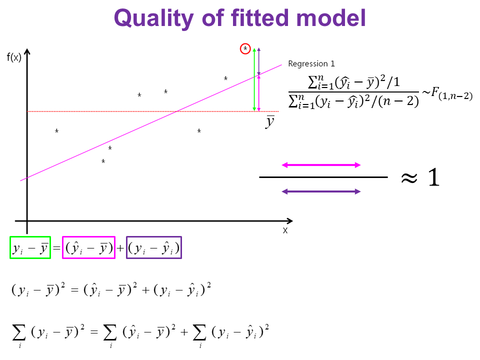

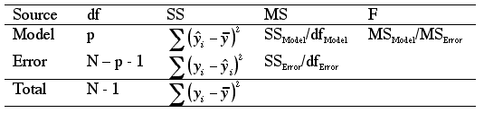

https://psychology.illinoisstate.edu/jccutti/psych340/fall02/oldlecturefiles/multiregression.html

## 가정에 대한 확인 (Assumption Checks)

### 자기상관성 (Autocorrelation test, Serial correlation)

- 자기상관성이란 연속적인 일련의 관측치들이 서로 상관되어 있을 때, 예를 들면, 현재의 자료와 서로 이웃하는 자료간에 일정한 관련성이 있는 경우 ($\epsilon_t$ 와 $\epsilon_t-1$ 간에 상관성)
- $E(\epsilon_i, \epsilon_{i+j}) \ne 0$: 오차가 자기상관성을 가짐
- 주로 시계열 자료에서 발생, 예 시간 $x_i$와 난방기구 판매량 $y_i$
- **Durbin-Watson (DW) test**
  $$\large d = \frac{\sum_{t = 2}^n(e_t-e_{t-1})^2}{\sum_i^ne_i^2}$$
- d = 2: 자기상관이 없음
- d = 0: (+) 의 자기상관
- d = 4: (-) 의 자기상관

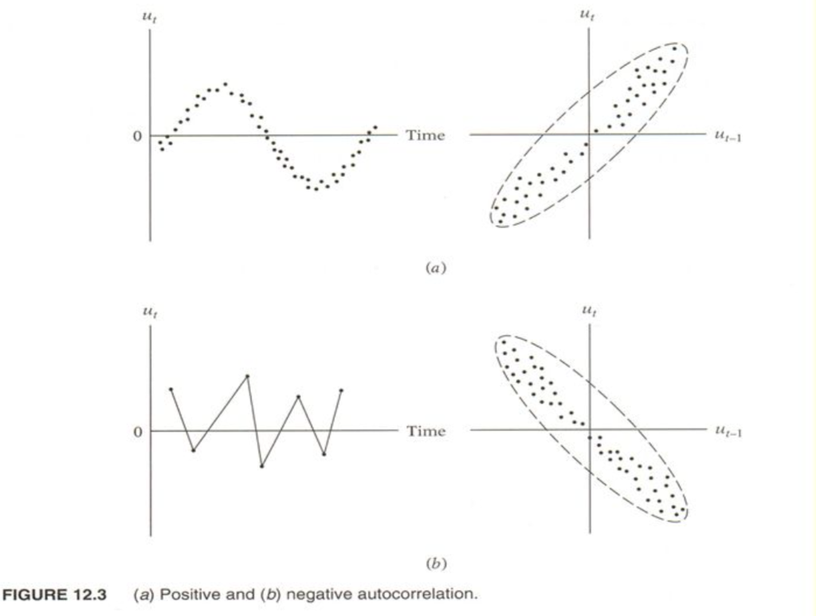

### Durbin-Watson (DW) test in r

```r
car::durbinWatsonTest(lm.result)
```

```
 lag Autocorrelation D-W Statistic p-value
   1            0.16          1.68   0.182
 Alternative hypothesis: rho != 0
```

### 결정계수 (Coefficient of determination)

- 추정한 선형 모형이 주어진 자료에 적합한 정도를 재는 척도
- 반응 변수의 변동량 중에서 적용한 모형으로 설명가능한 부분의 비율을 나타냄
- 0에서 1사이에 있으며, 반응변수과 독립변수에 의해서 모형적합이 잘 될 수록 1에 가까움
  $$\large R^2 = \frac{SSR}{SST}=1-\frac{SSE}{SST}$$

### 잔차 그림 (Residual plots)

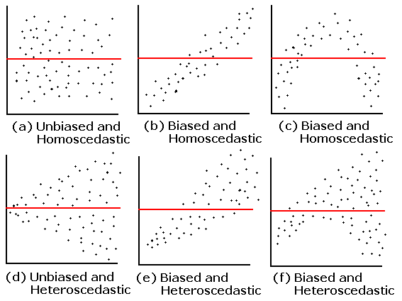

https://www.pinterest.co.kr/pin/527061962641283091

```r
url <- "https://i.pinimg.com/originals/55/e0/f9/55e0f97eba095204e8520e63f6446548.gif"
knitr::include_graphics(url)
```

### Multiple liear regression in r

```r
mtcars <- mtcars %>%
  mutate(cyl = factor(cyl))
mlm.result <- lm(mpg ~ ., data = mtcars)
summary(mlm.result)
```

```
Call:
lm(formula = mpg ~ ., data = mtcars)

Residuals:
   Min     1Q Median     3Q    Max
-3.473 -1.379 -0.066  1.051  4.391

Coefficients:
            Estimate Std. Error t value Pr(>|t|)
(Intercept)  17.8198    16.3060    1.09    0.287
cyl6         -1.6603     2.2623   -0.73    0.472
cyl8          1.6374     4.3157    0.38    0.708
disp          0.0139     0.0174    0.80    0.433
hp           -0.0461     0.0271   -1.70    0.104
drat          0.0264     1.6765    0.02    0.988
wt           -3.8062     1.8466   -2.06    0.053 .
qsec          0.6470     0.7220    0.90    0.381
vs            1.7474     2.2727    0.77    0.451
am            2.6173     2.0047    1.31    0.207
gear          0.7640     1.4567    0.52    0.606
carb          0.5094     0.9424    0.54    0.595
---
Signif. codes:  0 '***' 0.001 '**' 0.01 '*' 0.05 '.' 0.1 ' ' 1

Residual standard error: 2.58 on 20 degrees of freedom
Multiple R-squared:  0.882, Adjusted R-squared:  0.816
F-statistic: 13.5 on 11 and 20 DF,  p-value: 5.72e-07
```

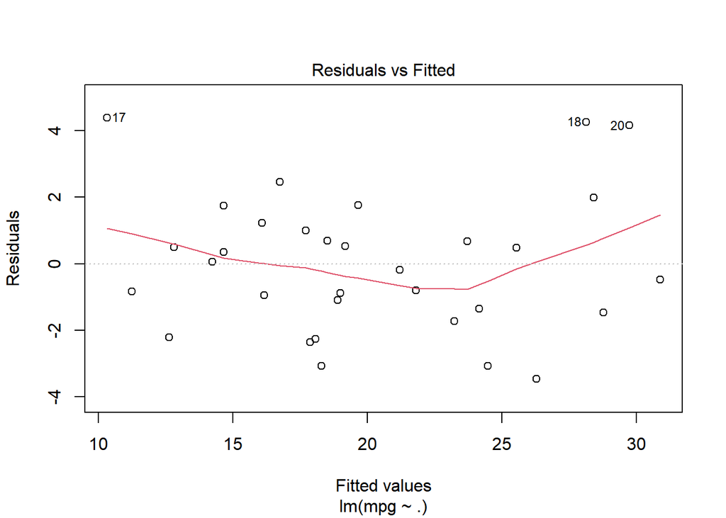

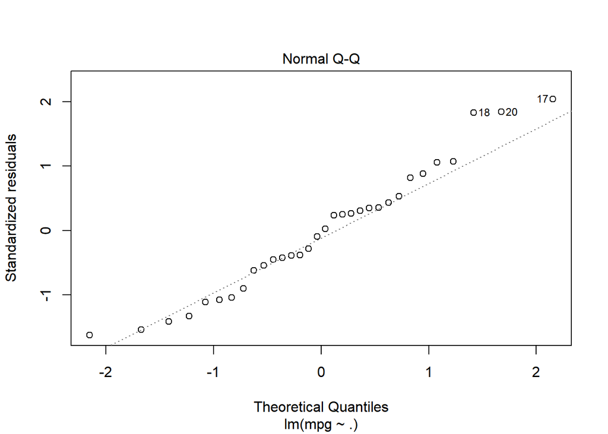

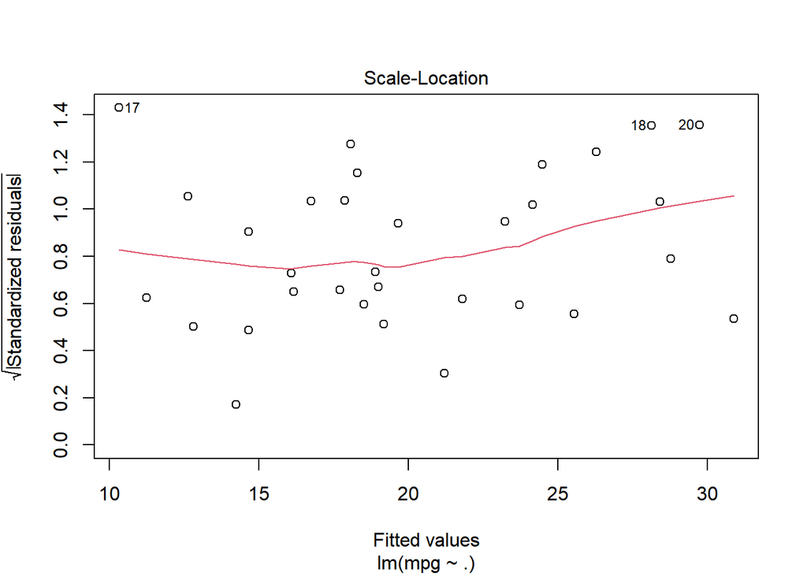

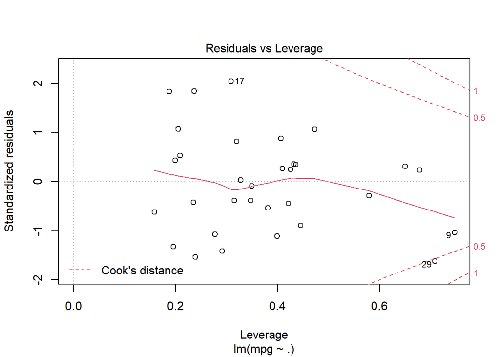

```r
plot(mlm.result)
```

### Multicollinearity in r

```r
car::vif(mlm.result)
```

```
      GVIF Df GVIF^(1/(2*Df))
cyl  36.35  2            2.46
disp 21.63  1            4.65
hp   16.08  1            4.01
drat  3.74  1            1.93
wt   15.18  1            3.90
qsec  7.74  1            2.78
vs    6.10  1            2.47
am    4.65  1            2.16
gear  5.37  1            2.32
carb 10.78  1            3.28
```

```r
mlm.result2 <- mtcars %>%
  select(-disp) %>%
  lm(mpg ~., data = .)

car::vif(mlm.result2)
```

```
      GVIF Df GVIF^(1/(2*Df))
cyl  33.75  2            2.41
hp   13.18  1            3.63
drat  3.69  1            1.92
wt    6.19  1            2.49
qsec  7.14  1            2.67
vs    6.04  1            2.46
am    4.65  1            2.16
gear  5.34  1            2.31
carb  7.03  1            2.65
```

```r
mlm.result3 <- mtcars %>%
  select(-c(disp, cyl)) %>%
  lm(mpg ~., data = .)

car::vif(mlm.result3)
```

```
  hp drat   wt qsec   vs   am gear carb
6.02 3.11 6.05 5.92 4.27 4.29 4.69 4.29
```

```r
summary(mlm.result3)
```

```
Call:
lm(formula = mpg ~ ., data = .)

Residuals:
   Min     1Q Median     3Q    Max
-3.819 -1.390 -0.305  1.227  4.518

Coefficients:
            Estimate Std. Error t value Pr(>|t|)
(Intercept)  13.8081    12.8858    1.07    0.295
hp           -0.0123     0.0165   -0.74    0.465
drat          0.8889     1.5206    0.58    0.565
wt           -2.6097     1.1588   -2.25    0.034 *
qsec          0.6398     0.6275    1.02    0.319
vs            0.0879     1.8899    0.05    0.963
am            2.4242     1.9123    1.27    0.218
gear          0.6939     1.3529    0.51    0.613
carb         -0.6129     0.5911   -1.04    0.311
---
Signif. codes:  0 '***' 0.001 '**' 0.01 '*' 0.05 '.' 0.1 ' ' 1

Residual standard error: 2.57 on 23 degrees of freedom
Multiple R-squared:  0.865, Adjusted R-squared:  0.819
F-statistic: 18.5 on 8 and 23 DF,  p-value: 2.63e-08
```

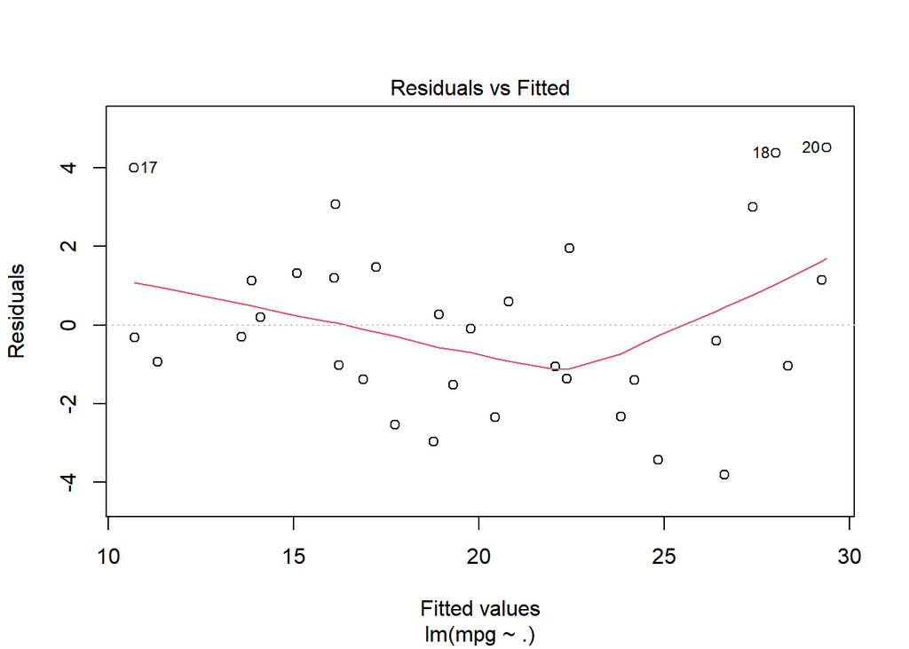

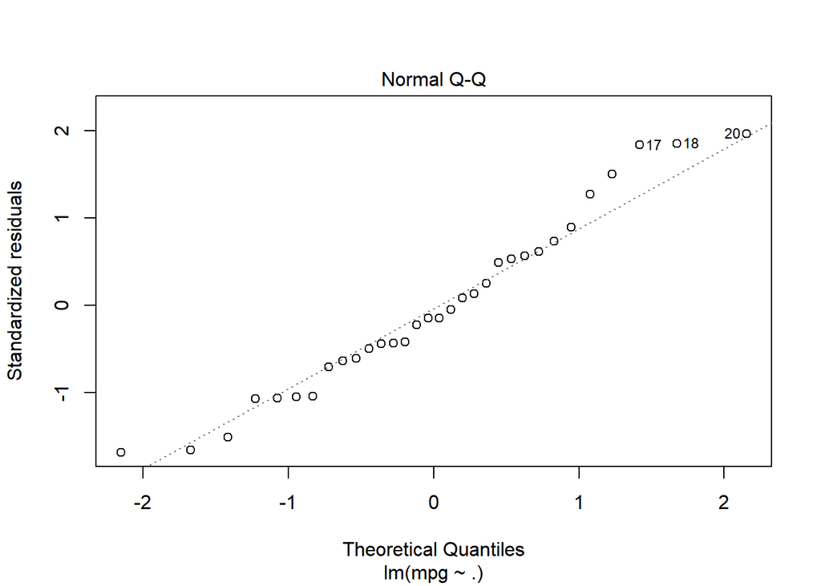

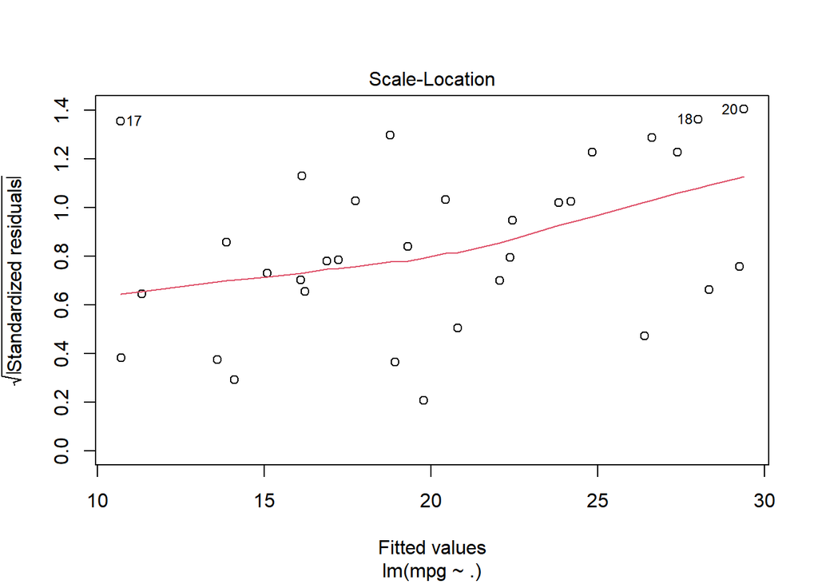

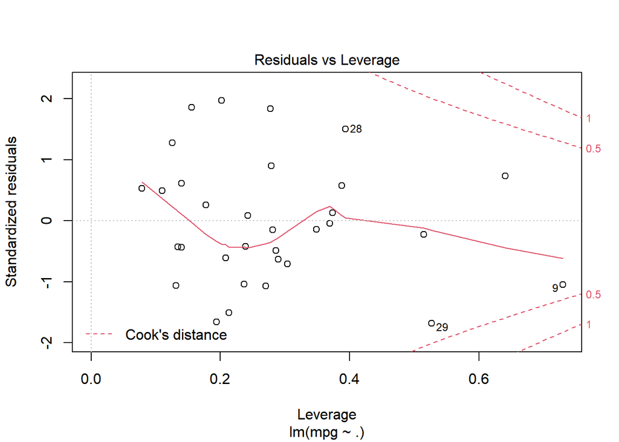

```r
plot(mlm.result3)
```

### Cook’s distance

- 각 각의 자료값이 예측치(predicted target) $\hat y$ 를 추정하는데 미치는 영향의 정도를 나타내는 통계량
- 값이 클수록 예측치(predicted target) $\hat y$ 를 추정하는데 영향을 많이 미침

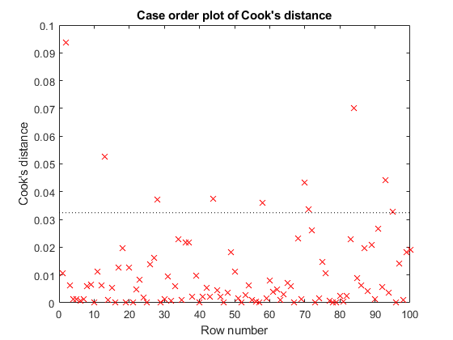

https://kr.mathworks.com/help/stats/cooks-distance.html

```r
url <- "https://kr.mathworks.com/help/examples/stats/win64/DetermineOutliersUsingCooksDistanceExample_01.png"
knitr::include_graphics(url)
```

### Cook’s distance in r

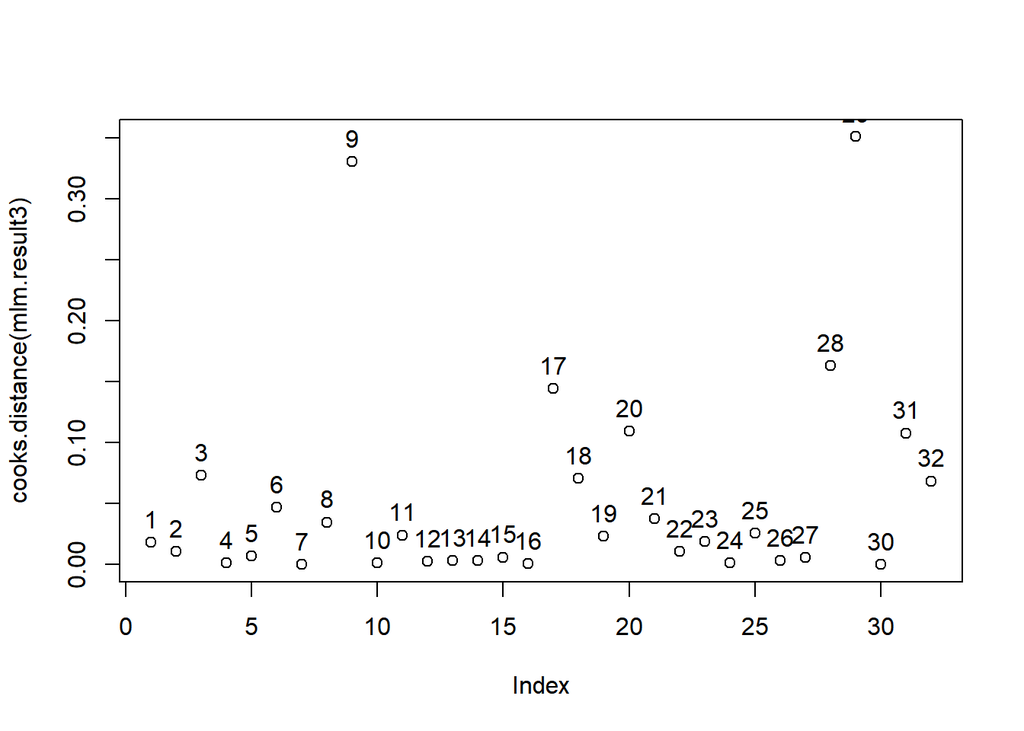

```r
plot(cooks.distance(mlm.result3))
text(cooks.distance(mlm.result3), pos = 3)
```

## Model Fit

### Bias and variance

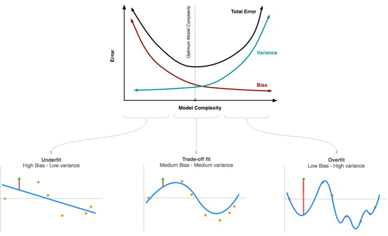

https://blog.naver.com/PostView.nhn?blogId=ckdgus1433&logNo=221594203319

```r
url <- "https://postfiles.pstatic.net/MjAxOTA3MjJfMjMg/MDAxNTYzNzk3Nzc0NDcw.VdLhR996Ys1uG0V5R_9UD6Wg4jZL3dI_3Phnu13mdY4g.OkHU-OcxcVk4R4KU7bI_xHCUEKh8Gfs_stvNrmBH02Ig.PNG.ckdgus1433/image.png?type=w773"
knitr::include_graphics(url)
```

### Ajusted $R^2$

- 비록 의미없는 변수들이라 해도 변수를 추가하면 할수록 $R^2$은 계속 증가
- 너무나 많은 변수들을 포함하면 모형의 추정및 예측에 문제가 생김 (과적합, Overfitting)

$$\large R_{adj}^2 = 1-\frac{SSE/(n-p)}{SST/(n-1)}$$

### AIC (Akaike Information Criterion) and BIC (Bayesian Information Criterion)

- $AIC = -2LogL + 2K$, K = 회귀계수의 수
- $BIC = -2LogL + Klogn$, n = 자료의 갯수
- 둘 다 값이 작을수록 최적의 모형에 가까움

### 평균제곱근 편차 (Root mean square error, RMSE)

$$\large RMSE = \sqrt{\frac{\sum_i^n(y_i-\hat y_i)^2}{n}}$$

### Overall F-test

- 모형 전체가 통계적으로 유의한 지를 검정

## Model Coefficients

### Omnibus test

- 각 요인의 수준 전체가 통계적으로 유의한 지를 검정
- Omnibus test에서 유의할 경우 Post-hoc test 를 진행

### 표준화 회귀계수 (Standardized coefficient (estimate))

- 각 변수들을 표준화 하여 얻어진 회귀계수

### Standardized coefficient in r

```r
summary(lm.beta::lm.beta(mlm.result3))
```

```
Call:
lm(formula = mpg ~ ., data = .)

Residuals:
   Min     1Q Median     3Q    Max
-3.819 -1.390 -0.305  1.227  4.518

Coefficients:
            Estimate Standardized Std. Error t value Pr(>|t|)
(Intercept) 13.80810      0.00000   12.88582    1.07    0.295
hp          -0.01225     -0.13937    0.01649   -0.74    0.465
drat         0.88894      0.07886    1.52061    0.58    0.565
wt          -2.60968     -0.42367    1.15878   -2.25    0.034 *
qsec         0.63983      0.18971    0.62752    1.02    0.319
vs           0.08786      0.00735    1.88992    0.05    0.963
am           2.42418      0.20071    1.91227    1.27    0.218
gear         0.69390      0.08495    1.35294    0.51    0.613
carb        -0.61286     -0.16424    0.59109   -1.04    0.311
---
Signif. codes:  0 '***' 0.001 '**' 0.01 '*' 0.05 '.' 0.1 ' ' 1

Residual standard error: 2.57 on 23 degrees of freedom
Multiple R-squared:  0.865, Adjusted R-squared:  0.819
F-statistic: 18.5 on 8 and 23 DF,  p-value: 2.63e-08
```